# iteration and list columns

Kennedy Wade

2025-10-28

## lists

In R, vectors are limited to a single data class – all elements are characters, or all numeric, or all logical. Trying to join the following vectors will result in coersion, as would creating vectors of mixed types.

```r
vec_numeric = 5:8
vec_char = c("My", "name", "is", "Kennedy")
vec_logical = c(TRUE, TRUE, TRUE, FALSE)
```

Lists provide a way to store anything you want. This flexibility is great, but is offset by a certain … clunkiness. Lists contain indexed elements, and the indexed elements themselves be scalars, vectors, or other things entirely.

```r
l = list(
  vec_numeric = 5:8,
  mat         = matrix(1:8, 2, 4),
  vec_logical = c(TRUE, FALSE),
  summary     = summary(rnorm(1000)))
l
```

```
## $vec_numeric
## [1] 5 6 7 8
##
## $mat
##      [,1] [,2] [,3] [,4]
## [1,]    1    3    5    7
## [2,]    2    4    6    8
##
## $vec_logical
## [1]  TRUE FALSE
##
## $summary
##     Min.  1st Qu.   Median     Mean  3rd Qu.     Max.
## -3.61693 -0.65902  0.04945  0.01906  0.68113  2.91706
```

## Makiing a list of these different dataframes

```r
list_norms =
  list(
    a = rnorm(20, 3, 1),
    b = rnorm(20, 0, 5),
    c = rnorm(20, 10, .2),
    d = rnorm(20, -3, 1)
  )
```

copy and paste the function from last time

```r
mean_and_sd = function(x){


   if (!is.numeric(x)) {
     stop( "The input x should be numeric")
   }

  if (length(x) <5) {
    stop("Only computw z scores when the input has 5 or more numbers")
  }

 mean_x = mean(x, na.rm = TRUE)
 sd_x = sd(x, na.rm = TRUE)

 tibble(
   mean = mean_x,
   sd = sd_x
 )

}
x_vec = rnorm(25, mean = 5, sd = 3)
mean_and_sd(x_vec)
```

```
## # A tibble: 1 × 2
##    mean    sd
##   <dbl> <dbl>
## 1  5.18  3.05
```

We can apply the mean_and_sd function to each element of list_norms using the lines below.

```r
mean_and_sd(list_norms[[1]])
```

```
## # A tibble: 1 × 2
##    mean    sd
##   <dbl> <dbl>
## 1  2.71  1.17
```

```r
mean_and_sd(list_norms[[2]])
```

```
## # A tibble: 1 × 2
##     mean    sd
##    <dbl> <dbl>
## 1 -0.540  4.35
```

```r
mean_and_sd(list_norms[[3]])
```

```
## # A tibble: 1 × 2
##    mean    sd
##   <dbl> <dbl>
## 1  10.0 0.233
```

```r
mean_and_sd(list_norms[[4]])
```

```
## # A tibble: 1 × 2
##    mean    sd
##   <dbl> <dbl>
## 1 -2.70 0.823
```

define an output list with the same number of entries as my target dataframe; a sequence to iterate over; and a for loop body that applies the mean_and_sd function for each sequence element and saves the result.

```r
output = vector("list", length = 4)

for (i in 1:4) {
  output[[i]] = mean_and_sd(list_norms[[i]])
}
```

use `map` to do the same thing: The map functions in purrr try to make the purpose of your code clear. Compare the loop above to the line below.

```r
output = map(list_norms, mean_and_sd)

output = map(list_norms, median)
```

check out some `map` variants

```r
map_dfr(list_norms, mean_and_sd, .id = "sample")
```

```
## # A tibble: 4 × 3
##   sample   mean    sd
##   <chr>   <dbl> <dbl>
## 1 a       2.71  1.17
## 2 b      -0.540 4.35
## 3 c      10.0   0.233
## 4 d      -2.70  0.823
```

```r
map_dfr(list_norms, median)
```

```
## # A tibble: 1 × 4
##       a      b     c     d
##   <dbl>  <dbl> <dbl> <dbl>
## 1  2.68 -0.370  10.0 -2.90
```

try to out a lsit into a datframe

```r
listcol_df =
  tibble(
   name = c("a","b", "c", "d"),
   sample = list_norms
  )
```

did this work????

```r
pull(listcol_df, name)
```

```
## [1] "a" "b" "c" "d"
```

```r
pull(listcol_df, "sample")
```

```
## $a
##  [1] 0.7926260 2.7234175 2.2519497 2.1044779 0.7532239 2.8408943 4.6482628
##  [8] 2.3262170 2.6426658 3.4257915 2.6430362 2.9517155 4.3001848 2.9833169
## [15] 3.9900268 1.9485649 0.8801418 4.7769926 1.8942323 3.2715738
##
## $b
##  [1]  2.67652081  6.07327501  0.08719399  3.50953323  3.44450799 -4.46048836
##  [7] -2.51889206 -3.47844072  4.56082112  3.80783180  2.38869552  3.11187447
## [13] -6.50961914 -2.56416963  2.81466758 -4.36966282 -7.72266934 -8.04618227
## [19] -2.77653656 -0.82637893
##
## $c
##  [1]  9.948269 10.578404 10.258821  9.946125  9.876635 10.109214  9.918003
##  [8] 10.066287  9.750577 10.099121 10.052073 10.004972  9.870484  9.582012
## [15]  9.544391  9.878161 10.000647 10.201553 10.128080 10.195559
##
## $d
##  [1] -1.585476 -3.395431 -3.474356 -2.229521 -1.681725 -3.260586 -3.271472
##  [8] -2.698970 -1.227460 -3.931752 -1.732415 -3.460342 -2.822676 -1.865560
## [15] -1.868536 -2.979688 -3.029883 -3.988603 -2.488417 -3.067246
```

yes it did!!!!!

can i apply `mean_and_sd`

```r
mean_and_sd(pull(listcol_df, sample)[[1]])
```

```
## # A tibble: 1 × 2
##    mean    sd
##   <dbl> <dbl>
## 1  2.71  1.17
```

```r
mean_and_sd(pull(listcol_df, sample)[[2]])
```

```
## # A tibble: 1 × 2
##     mean    sd
##    <dbl> <dbl>
## 1 -0.540  4.35
```

```r
mean_and_sd(pull(listcol_df, sample)[[3]])
```

```
## # A tibble: 1 × 2
##    mean    sd
##   <dbl> <dbl>
## 1  10.0 0.233
```

```r
mean_and_sd(pull(listcol_df, sample)[[4]])
```

```
## # A tibble: 1 × 2
##    mean    sd
##   <dbl> <dbl>
## 1 -2.70 0.823
```

iterate using `map`

```r
map(pull(listcol_df, sample),mean_and_sd)
```

```
## $a
## # A tibble: 1 × 2
##    mean    sd
##   <dbl> <dbl>
## 1  2.71  1.17
##
## $b
## # A tibble: 1 × 2
##     mean    sd
##    <dbl> <dbl>
## 1 -0.540  4.35
##
## $c
## # A tibble: 1 × 2
##    mean    sd
##   <dbl> <dbl>
## 1  10.0 0.233
##
## $d
## # A tibble: 1 × 2
##    mean    sd
##   <dbl> <dbl>
## 1 -2.70 0.823
```

addiing a column…

```r
listcol_df |>
  mutate(
    summary = map(sample, mean_and_sd)
  )
```

```
## # A tibble: 4 × 3
##   name  sample       summary
##   <chr> <named list> <named list>
## 1 a     <dbl [20]>   <tibble [1 × 2]>
## 2 b     <dbl [20]>   <tibble [1 × 2]>
## 3 c     <dbl [20]>   <tibble [1 × 2]>
## 4 d     <dbl [20]>   <tibble [1 × 2]>
```

```r
listcol_df <- listcol_df |>
  mutate(summary = map(sample, mean_and_sd))

listcol_df |>
  select( -sample) |>
  unnest(summary)
```

```
## # A tibble: 4 × 3
##   name    mean    sd
##   <chr>  <dbl> <dbl>
## 1 a      2.71  1.17
## 2 b     -0.540 4.35
## 3 c     10.0   0.233
## 4 d     -2.70  0.823
```

## Revisiting NSDUH

```r
nsduh_url = "http://samhda.s3-us-gov-west-1.amazonaws.com/s3fs-public/field-uploads/2k15StateFiles/NSDUHsaeShortTermCHG2015.htm"

nsduh_html = read_html(nsduh_url)

data_marj =
  nsduh_html |>
  html_table() |>
  nth(1) |>
  slice(-1) |>
  select(-contains("P Value")) |>
  pivot_longer(
    -State,
    names_to = "age_year",
    values_to = "percent") |>
  separate(age_year, into = c("age", "year"), sep = "\\(") |>
  mutate(
    year = str_replace(year, "\\)", ""),
    percent = str_replace(percent, "[a-c]$", ""),
    percent = as.numeric(percent)) |>
  filter(!(State %in% c("Total U.S.", "Northeast", "Midwest", "South", "West")))
```

```r
nsduh_table <- function(html, table_num) {

  table =
    html |>
    html_table() |>
    nth(table_num) |>
    slice(-1) |>
    select(-contains("P Value")) |>
    pivot_longer(
      -State,
      names_to = "age_year",
      values_to = "percent") |>
    separate(age_year, into = c("age", "year"), sep = "\\(") |>
    mutate(
      year = str_replace(year, "\\)", ""),
      percent = str_replace(percent, "[a-c]$", ""),
      percent = as.numeric(percent)) |>
    filter(!(State %in% c("Total U.S.", "Northeast", "Midwest", "South", "West")))

  table
}

nsduh_table(nsduh_html, table_num = 1)
```

```
## # A tibble: 510 × 4
##    State   age   year      percent
##    <chr>   <chr> <chr>       <dbl>
##  1 Alabama 12+   2013-2014    9.98
##  2 Alabama 12+   2014-2015    9.6
##  3 Alabama 12-17 2013-2014    9.9
##  4 Alabama 12-17 2014-2015    9.71
##  5 Alabama 18-25 2013-2014   27.0
##  6 Alabama 18-25 2014-2015   26.1
##  7 Alabama 26+   2013-2014    7.1
##  8 Alabama 26+   2014-2015    6.81
##  9 Alabama 18+   2013-2014    9.99
## 10 Alabama 18+   2014-2015    9.59
## # ℹ 500 more rows
```

```r
nsduh_table(nsduh_html, table_num = 2)
```

```
## # A tibble: 510 × 4
##    State   age   year      percent
##    <chr>   <chr> <chr>       <dbl>
##  1 Alabama 12+   2013-2014    5.57
##  2 Alabama 12+   2014-2015    5.35
##  3 Alabama 12-17 2013-2014    4.98
##  4 Alabama 12-17 2014-2015    5.16
##  5 Alabama 18-25 2013-2014   15.0
##  6 Alabama 18-25 2014-2015   14.3
##  7 Alabama 26+   2013-2014    4.03
##  8 Alabama 26+   2014-2015    3.86
##  9 Alabama 18+   2013-2014    5.63
## 10 Alabama 18+   2014-2015    5.37
## # ℹ 500 more rows
```

```r
nsduh_table(nsduh_html, table_num = 3)
```

```
## # A tibble: 510 × 4
##    State   age   year      percent
##    <chr>   <chr> <chr>       <dbl>
##  1 Alabama 12+   2013-2014    1.42
##  2 Alabama 12+   2014-2015    1.49
##  3 Alabama 12-17 2013-2014    4.46
##  4 Alabama 12-17 2014-2015    4.36
##  5 Alabama 18-25 2013-2014    6.04
##  6 Alabama 18-25 2014-2015    6.39
##  7 Alabama 26+   2013-2014    0.15
##  8 Alabama 26+   2014-2015    0.2
##  9 Alabama 18+   2013-2014    0.95
## 10 Alabama 18+   2014-2015    1.05
## # ℹ 500 more rows
```

try this with a `for` loop

```r
output = vector("list", length = 3)

for (i in 1:3) {
  output[[i]] = nsduh_table(nsduh_html, i)
}
```

do this with `map`

```r
map(1:3, nsduh_table, html = nsduh_html)
```

```
## [[1]]
## # A tibble: 510 × 4
##    State   age   year      percent
##    <chr>   <chr> <chr>       <dbl>
##  1 Alabama 12+   2013-2014    9.98
##  2 Alabama 12+   2014-2015    9.6
##  3 Alabama 12-17 2013-2014    9.9
##  4 Alabama 12-17 2014-2015    9.71
##  5 Alabama 18-25 2013-2014   27.0
##  6 Alabama 18-25 2014-2015   26.1
##  7 Alabama 26+   2013-2014    7.1
##  8 Alabama 26+   2014-2015    6.81
##  9 Alabama 18+   2013-2014    9.99
## 10 Alabama 18+   2014-2015    9.59
## # ℹ 500 more rows
##
## [[2]]
## # A tibble: 510 × 4
##    State   age   year      percent
##    <chr>   <chr> <chr>       <dbl>
##  1 Alabama 12+   2013-2014    5.57
##  2 Alabama 12+   2014-2015    5.35
##  3 Alabama 12-17 2013-2014    4.98
##  4 Alabama 12-17 2014-2015    5.16
##  5 Alabama 18-25 2013-2014   15.0
##  6 Alabama 18-25 2014-2015   14.3
##  7 Alabama 26+   2013-2014    4.03
##  8 Alabama 26+   2014-2015    3.86
##  9 Alabama 18+   2013-2014    5.63
## 10 Alabama 18+   2014-2015    5.37
## # ℹ 500 more rows
##
## [[3]]
## # A tibble: 510 × 4
##    State   age   year      percent
##    <chr>   <chr> <chr>       <dbl>
##  1 Alabama 12+   2013-2014    1.42
##  2 Alabama 12+   2014-2015    1.49
##  3 Alabama 12-17 2013-2014    4.46
##  4 Alabama 12-17 2014-2015    4.36
##  5 Alabama 18-25 2013-2014    6.04
##  6 Alabama 18-25 2014-2015    6.39
##  7 Alabama 26+   2013-2014    0.15
##  8 Alabama 26+   2014-2015    0.2
##  9 Alabama 18+   2013-2014    0.95
## 10 Alabama 18+   2014-2015    1.05
## # ℹ 500 more rows
```

do all this in a dtaframe

```r
nsduh_df =
  tibble(
    name = c("marj year", "marj month", "marj year"),
    number = 1:3
  ) |>

  mutate(
    table = map(number, nsduh_table,html = nsduh_html)
  ) |>

  unnest(table)
```

## lets look at the weather data

```r
library(p8105.datasets)
data("weather_df")
```

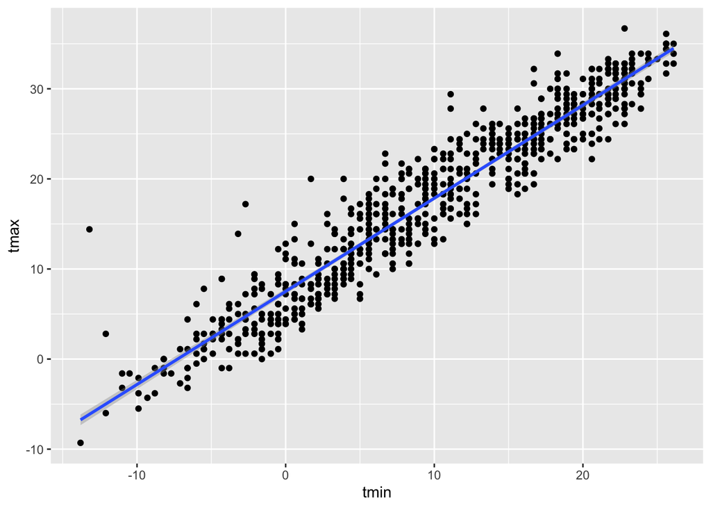

```r
weather_df |>
  filter(name =="CentralPark_NY") |>
  ggplot(aes( x = tmin, y = tmax)) +
  geom_point() +
  geom_smooth(method = "lm")
```

lets do regression

```r
weather_df |>
  filter(name =="CentralPark_NY") |>
 lm(tmax ~ tmin, data = _)
```

```
##
## Call:
## lm(formula = tmax ~ tmin, data = filter(weather_df, name == "CentralPark_NY"))
##
## Coefficients:
## (Intercept)         tmin
##       7.514        1.034
```

```r
 weather_df |>
  filter(name =="Molokai_HI") |>
 lm(tmax ~ tmin, data = _)
```

```
##
## Call:
## lm(formula = tmax ~ tmin, data = filter(weather_df, name == "Molokai_HI"))
##
## Coefficients:
## (Intercept)         tmin
##     21.7547       0.3222
```

```r
 weather_df |>
  filter(name =="Waterhole_WA") |>
 lm(tmax ~ tmin, data = _)
```

```
##
## Call:
## lm(formula = tmax ~ tmin, data = filter(weather_df, name == "Waterhole_WA"))
##
## Coefficients:
## (Intercept)         tmin
##       7.532        1.137
```

lets iterate differently…

```r
weather_nest <-weather_df |>
  nest(data = date:tmin)
```

```r
lm(tmax ~tmin, data = pull(weather_nest, data)[[1]])
```

```
##
## Call:
## lm(formula = tmax ~ tmin, data = pull(weather_nest, data)[[1]])
##
## Coefficients:
## (Intercept)         tmin
##       7.514        1.034
```

```r
lm(tmax ~tmin, data = pull(weather_nest, data)[[2]])
```

```
##
## Call:
## lm(formula = tmax ~ tmin, data = pull(weather_nest, data)[[2]])
##
## Coefficients:
## (Intercept)         tmin
##     21.7547       0.3222
```

```r
lm(tmax ~tmin, data = pull(weather_nest, data)[[3]])
```

```
##
## Call:
## lm(formula = tmax ~ tmin, data = pull(weather_nest, data)[[3]])
##
## Coefficients:
## (Intercept)         tmin
##       7.532        1.137
```

do this using `map`

```r
weather_lm =function(df) {

  lm(tmax ~ tmin, data = df)

}
```

```r
map(pull(weather_nest, data), weather_lm)
```

```
## [[1]]
##
## Call:
## lm(formula = tmax ~ tmin, data = df)
##
## Coefficients:
## (Intercept)         tmin
##       7.514        1.034
##
##
## [[2]]
##
## Call:
## lm(formula = tmax ~ tmin, data = df)
##
## Coefficients:
## (Intercept)         tmin
##     21.7547       0.3222
##
##
## [[3]]
##
## Call:
## lm(formula = tmax ~ tmin, data = df)
##
## Coefficients:
## (Intercept)         tmin
##       7.532        1.137
```

```r
weather_nest |>
  mutate(
     lm_fits = map(data, weather_lm)
  )
```

```
## # A tibble: 3 × 4
##   name           id          data               lm_fits
##   <chr>          <chr>       <list>             <list>
## 1 CentralPark_NY USW00094728 <tibble [730 × 4]> <lm>
## 2 Molokai_HI     USW00022534 <tibble [730 × 4]> <lm>
## 3 Waterhole_WA   USS0023B17S <tibble [730 × 4]> <lm>
```